# Sengunda Entrega del proyecto

2022-11-24

```r
library(reshape)
library(reshape2)
```

[figure not shown]

```r
library(plotrix)
library(readr)
library(haven)
library(modelsummary)
library(dplyr)
library(tidyverse)
library(ggplot2)
library(hablar)
library(readxl)
library(GGally)
library(psych)
```

**Prevención de desbordamientos en el Sistema Hidráulico Mayor de Enero a Setiembre del 2022**

- Obtención de datos públicos [Aquí](https://www.datosabiertos.gob.pe/dataset/datos-hidrometereol%C3%B3gicos-gobierno-regional-piura)
- Proveniencia de los datos : **Proyecto Especial Chira Piura**

[figure not shown]

# Introducción

## *Relevancia*

Para prevenir desastres es importante la observación, interpretación y el análisis de los datos hidrometeorológicos, ya que nos sirve para predecir temperaturas, precipitaciones, infiltración de agua, tiempos de retorno, caudales, crecidas de ríos o inundaciones. Lo que se busca con este tema es informar si en el periodo del 2022 hasta setiembre se encontraron caudales anormales que puedan ser peligrosas para la represa y determinar en qué meses en el distrito de piura se producen mayores o menores caudales a causa de lluvia. Nos dimos cuenta que con esta base de datos podríamos determinar en qué meses en el distrito provincial de Piura se produce un mayor o menos caudal.

## *Planificación*

A continuación presentaremos un diagrama de Grantt, que usamos para una mejor visualización del repartimiento de actividades del proyecto.

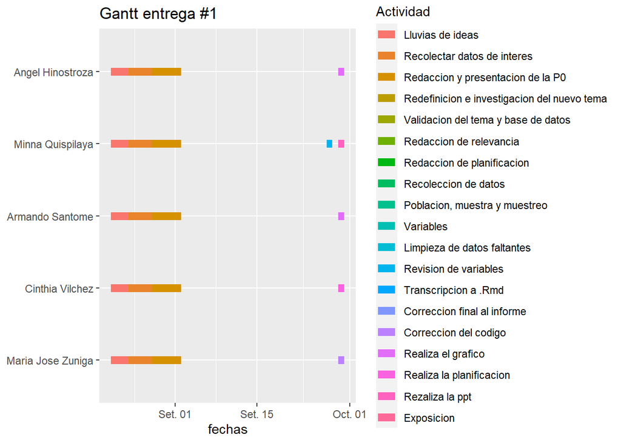

# *Datos*

## *Recolección de datos*

Investigamos diferentes bases de datos que esten de acuerdo a nuestro interés, se buscaron temas en la “Plataforma Nacional de Datos Abiertos”. En esta plataforma encontramos una base datos sobre los Datos Hidrometereológicos Gobierno Regional Piura, nos intereso que podríamos hacer con estos datos y decidimos trabajarlo.

Además, cumplía con los requerimientos necesarios para poder usarla en nuestro proyecto y peretenece a las bases de datos oficiales del gobierno peruano, es decir, la fiabilidad de sus procesos de recolección es alta, ya que podemos asegurar que sus cifras verídicas y verificadas.

## Variables

Para la elección de nuestro tema se identificaron 2 tipos de variables: Cuantitativas y Cualitativas

[output not shown]

**Variables cuantitativas:**

**Variable cualitativa:**

- Cuenta, tipo cualitativa nominal y su restricción es que sea nombre de la cuenca, río, estructura natural o artificial con caudal del departamento de Piura.
- Estación, tipo cualitativa nominal y su restricción es que sea únicamente nombre de las estaciones hidrológicas de Piura.
- Unidad de medida, tipo cualitativa nominal y su restricción es que se denote de una sola forma m3/s.
- Tipo de estación, tipo cualitativa nominal y presenta restricción en solo tener tres opciones (hidrológica, hidrométrica y presa)
- Departamento, tipo cualitativo nominal y su restricción es que solo se evalúa el departamento de Piura.
- Provincia, tipo cualitativo nominal y su restricción es que se solo se considera las provincia de Piura (Piura, Ayabaca, Huancabamba, Morropón, Paita, Sullana, Talara y Sechura)
- Distrito, tipo cualitativa nominal y su restricción es que solo se pueden insertar los distritos de las provincias de Piura donde están ubicadas las estaciones hidrometeorológicas.

# Limpieza de base de datos

Lo que haremos será leer la base de datos, verificar las observaciones observaciones y si las variables son adecuadas o necesitan alguna modificación como cambiarle su nombre o tipo.

```r
DF<-read_csv("DATOS_HIDROMETEREOLOGICOS.csv")
```

```r
DF %>% select(c(1:13)) -> DF
```

Ahora, verificaremos si nuestra base de datos tiene datos faltantes.

```r
unique(DF$ESTACION)
```

```
##  [1] "CANAL PRINCIPAL"        "PTE. SANCHEZ CERRO"     "COTE EMBALSE"
##  [4] "EL PAPAYO"              "TAMBOGRANDE"            "PTE. NACARA"
##  [7] "CANAL NORTE"            "RIO CHIRA(SULLANA)"     "COTA EMBALSE"
## [10] "CURUMUY"                "CHECK(KM 29+900)"       "TOTAL SALIDA"
## [13] "EVAPORACION"            "C. HUAYPIRA"            "C. DERIVACION"
## [16] "C. MIGUEL CHECA"        "TOTAL RIO CHIRA"        "RIO CHIRA - TUNEL"
## [19] "RIO CHIRA - ALIVIADERO" "INCREMENTO VOL"         "VOLUMEN"
## [22] "COTA REPRESA"           "ENTRADA"                "PARAJE GRANDE"
## [25] "ARDILLA"                "EL CIRUELO"             "PUENTE INTERNACIONAL"
```

```r
sum(is.na(DF))
```

```
## [1] 0
```

También, comprobaremos si todas las observaciones están completas.

```r
sum(!complete.cases(DF))
```

```
## [1] 0
```

Como nuestra base de datos no tiene ningun dato faltante ni alguna observación incompleta, procederemos a verificar que las variables esten correctas.

Primero, revisaremos si los nombres son adecuados para cada variable.

```r
names(DF)
```

```
##  [1] "FECHA_CORTE"   "FECHA_MUESTRA" "CUENTA"        "ESTACION"
##  [5] "UNIDAD_MEDIDA" "TIPO_ESTACION" "DEPARTAMENTO"  "PROVINCIA"
##  [9] "DISTRITO"      "UBIGEO"        "CAUDAL07H"     "PROMEDIO24H"
## [13] "MAXIMA24H"
```

Consideramos que los nombres son adecuados debido porque cualquier persona que le interezca nuestro trabajo debería tener la posibilidad de comprender el nombre de las variables. Sin embargo, en el caso de la variable “CUENTA” está mal redactada por lo que necesita un cambio.

Cambiamos las variables FECHA_MUESTRA y FECHA_CORTE al formato fecha. También, corregimos el Dato “MorropOn” para que este correctamente escrito.

```r
DF %>% convert(chr(FECHA_CORTE,FECHA_MUESTRA)) ->DF
mutate(DF, Fecha_Corte = as.Date(paste(substr(c(DF$FECHA_CORTE),5,6),substr(c(DF$FECHA_CORTE),7,8),substr(c(DF$FECHA_CORTE),1,4), sep = "/"),"%m/%d/%Y")) -> DF
mutate(DF, Fecha_Muestra = as.Date(paste(substr(c(DF$FECHA_MUESTRA),5,6),substr(c(DF$FECHA_MUESTRA),7,8),substr(c(DF$FECHA_MUESTRA),1,4), sep = "/"),"%m/%d/%Y")) -> DF
```

También, corregimos el Dato “MorropOn” para que este correctamente escrito.

```r
provincias_corregido <- replace(DF$PROVINCIA,DF$PROVINCIA == "MorropOn","Morropon")
DF$PROVINCIA = provincias_corregido

DF %>% relocate(Fecha_Corte,Fecha_Muestra) -> DF
DF %>% select(-(FECHA_CORTE:FECHA_MUESTRA)) -> DF
DF <- rename(DF, FECHA_CORTE = Fecha_Corte
             ,FECHA_MUESTRA = Fecha_Muestra,
             CUENCA = CUENTA)
```

La última revisión que le daremos a las variables, es si su tipo concuerda con la información en cada columna.

```r
glimpse(DF)
```

```
## Rows: 6,723
## Columns: 13
## $ FECHA_CORTE   <date> 2022-09-06, 2022-09-06, 2022-09-06, 2022-09-06, 2022-09~
## $ FECHA_MUESTRA <date> 2022-09-06, 2022-09-06, 2022-09-06, 2022-09-06, 2022-09~
## $ CUENCA        <chr> "PRESA EJIDOS", "PRESA EJIDOS", "PRESA EJIDOS", "RIO PIU~
## $ ESTACION      <chr> "CANAL PRINCIPAL", "PTE. SANCHEZ CERRO", "COTE EMBALSE",~
## $ UNIDAD_MEDIDA <chr> "m3/s", "m3/s", "msnm", "m3/s", "m3/s", "m3/s", "m3/s", ~
## $ TIPO_ESTACION <chr> "HIDROMETRICA", "HIDROLOGICA", "PRESA", "HIDROLOGICA", "~
## $ DEPARTAMENTO  <chr> "Piura", "Piura", "Piura", "Piura", "Piura", "Piura", "P~
## $ PROVINCIA     <chr> "Piura", "Piura", "Piura", "Piura", "Piura", "Morropon",~
## $ DISTRITO      <chr> "Castilla", "Castilla", "Castilla", "Castilla", "Tambo G~
## $ UBIGEO        <dbl> 200104, 200104, 200104, 200104, 200114, 200401, 200601, ~
## $ CAUDAL07H     <dbl> 12.70, 0.00, 30.49, 0.00, 0.00, 0.00, 22.00, 5.00, 36.97~
## $ PROMEDIO24H   <dbl> 12.90, 0.00, 0.00, 0.00, 0.00, 0.00, 21.85, 5.00, 0.00, ~
## $ MAXIMA24H     <dbl> 0.00, 0.00, 30.64, 0.00, 0.00, 0.00, 0.00, 5.00, 36.97, ~
```

No se encuentra ningun error en el tipo de variables, así que la limpieza de la base de datos esta terminada.

```r
DF
```

```
## # A tibble: 6,723 x 13
##    FECHA_CORTE FECHA_MUESTRA CUENCA         ESTACION UNIDAD_MEDIDA TIPO_ESTACION
##    <date>      <date>        <chr>          <chr>    <chr>         <chr>
##  1 2022-09-06  2022-09-06    PRESA EJIDOS   CANAL P~ m3/s          HIDROMETRICA
##  2 2022-09-06  2022-09-06    PRESA EJIDOS   PTE. SA~ m3/s          HIDROLOGICA
##  3 2022-09-06  2022-09-06    PRESA EJIDOS   COTE EM~ msnm          PRESA
##  4 2022-09-06  2022-09-06    RIO PIURA      EL PAPA~ m3/s          HIDROLOGICA
##  5 2022-09-06  2022-09-06    RIO PIURA      TAMBOGR~ m3/s          HIDROLOGICA
##  6 2022-09-06  2022-09-06    RIO PIURA      PTE. NA~ m3/s          HIDROMETRICA
##  7 2022-09-06  2022-09-06    PRESA SULLANA  CANAL N~ m3/s          HIDROLOGICA
##  8 2022-09-06  2022-09-06    PRESA SULLANA  RIO CHI~ m3/s          HIDROLOGICA
##  9 2022-09-06  2022-09-06    PRESA SULLANA  COTA EM~ msnm          PRESA
## 10 2022-09-06  2022-09-06    PUNTOS DE CON~ CURUMUY  m3/s          HIDROMETRICA
## # i 6,713 more rows
## # i 7 more variables: DEPARTAMENTO <chr>, PROVINCIA <chr>, DISTRITO <chr>,
## #   UBIGEO <dbl>, CAUDAL07H <dbl>, PROMEDIO24H <dbl>, MAXIMA24H <dbl>
```

# Análisis descriptivo

```r
summary(DF$CAUDAL07H)
```

```
##    Min. 1st Qu.  Median    Mean 3rd Qu.    Max.
##    0.00    0.00    7.70   40.90   36.58 1224.42
```

```r
summary(DF$MAXIMA24H)
```

```
##    Min. 1st Qu.  Median    Mean 3rd Qu.    Max.
##    0.00    0.00    5.50   45.42   36.93 1224.42
```

```r
unique(DF$PROVINCIA)
```

```
## [1] "Piura"    "Morropon" "Sullana"  "Ayabaca"
```

**Gráfico de barras del caudal promedio por provincia**

Verificaremos si se en este caso podemos hacer un diagrama de barras con las variables que queremos evaluar.

```r
table(DF$PROVINCIA, useNA = "always")
```

```
##
##  Ayabaca Morropon    Piura  Sullana     <NA>
##      747      249     1494     4233        0
```

Concluimos, que si es válido y eficiente hacer un diagrama de barras.

Queremos graficar las provincias con mayor caudal promedio, para eso promediaremos todos los datos del CAUDALPROM24H por provincia.

```
## # A tibble: 6,723 x 2
##    PROVINCIA PROMEDIO24H
##    <chr>           <dbl>
##  1 Piura            12.9
##  2 Piura             0
##  3 Piura             0
##  4 Piura             0
##  5 Piura             0
##  6 Morropon          0
##  7 Sullana          21.8
##  8 Sullana           5
##  9 Sullana           0
## 10 Piura            14.3
## # i 6,713 more rows
```

```
## [1] 11.26771
```

```
## [1] 47.42079
```

```
## [1] 13.71655
```

```
## [1] 55.03246
```

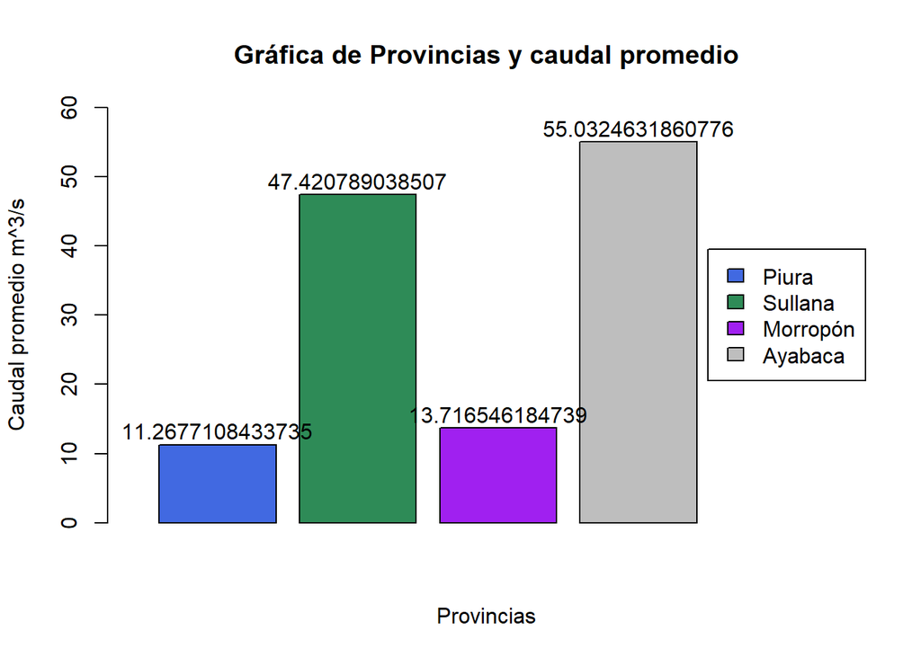

La gráfica que se aprecia nos muestra el promedio de los caudales promedio medidos en la base de datos, los cuáles están divididos en las provincias Piura, Sullana, Morropón y Ayabaca, en ese orden.

Lo que podemos obtener de está gráfica es como el promedio del caudal varía respecto a qué provincia te encuentres, si existe una relación entre estas variables debido que dependiendo de lugar geográfico, los factores varían. Por ejemplo, en base a las gráficas y datos que obtuvimos, tenemos que, en promedio, Ayabaca sería la zona que tiene más lluvias, siguiéndole Sullana. Por otro lado, tenemos a la provincia de Piura, que es la región con menor cantidad de lluvias del departamento debido a que tiene el promedio menor de caudal en comparación a las otras provincias.

**Análisis de la variable caudal 07H y provincias: Boxplot**

Hagamos una tabla de frecuencias para la variable provincias.

```r
table("Provincias"=DF$PROVINCIA, useNA = "ifany") / nrow(DF)
```

```
## Provincias
##    Ayabaca   Morropon      Piura    Sullana
## 0.11111111 0.03703704 0.22222222 0.62962963
```

Como se puede observar aproximadamente el 63% de los datos hidrologicos le pertenece a Sullana, mientras solo un 11% le pertenece a Ayabaca, por lo que podemos decir que en la pronvincia de Sullana se hicieron una mayor toma de datos que en la provincia de Ayabaca.

Toma de datos de la cuenca a las 7H con respecto a las Provincias.

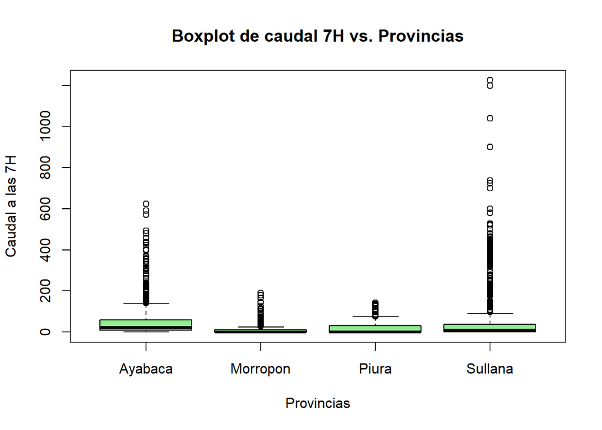

```r
boxplot(DF$CAUDAL07H~DF$PROVINCIA, col="lightgreen", main="Boxplot de caudal 7H vs. Provincias", ylab="Caudal a las 7H", xlab="Provincias")
```

En está gráfica se evidencia como la mayoría de los datos se encuentran entre 200 y 0, es decir, son datos muy pequeños. Sin embargo, hay datos que son atípicos, pero con una gran diferencia con respecto a la mayoría.

**Gráfico de PUNTOS del Caudal promedio en cada mes**

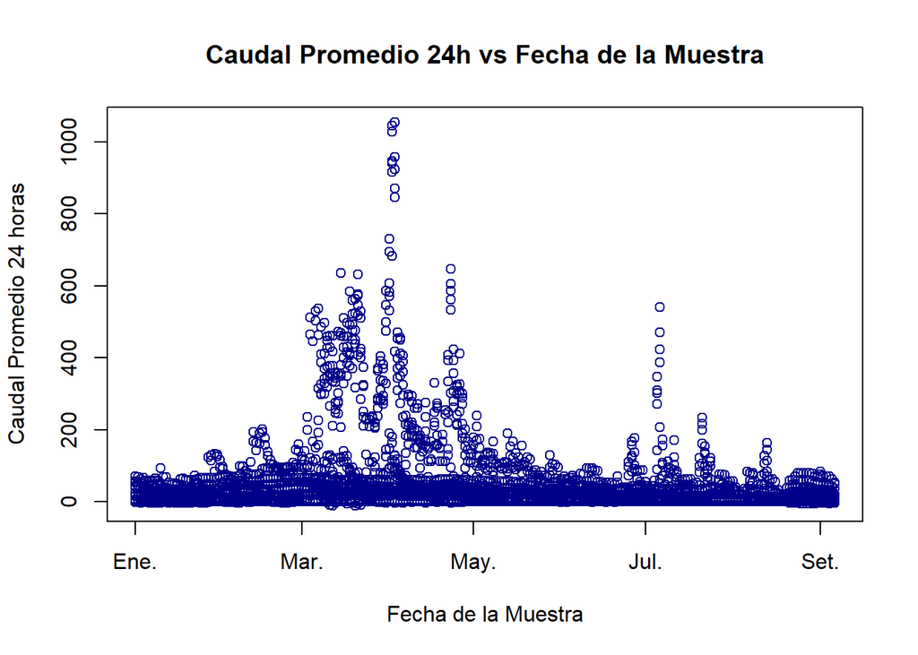

En cuanto al tiempo discreto, es decir, contando en meses, podemos obtener la siguiente gráfica:

```r
Fecha_muestra <- DF[1:6723, c(2,12)]
Fecha_muestra
```

```
## # A tibble: 6,723 x 2
##    FECHA_MUESTRA PROMEDIO24H
##    <date>              <dbl>
##  1 2022-09-06           12.9
##  2 2022-09-06            0
##  3 2022-09-06            0
##  4 2022-09-06            0
##  5 2022-09-06            0
##  6 2022-09-06            0
##  7 2022-09-06           21.8
##  8 2022-09-06            5
##  9 2022-09-06            0
## 10 2022-09-06           14.3
## # i 6,713 more rows
```

```r
mode <- function(x) {
   return(as.numeric(names(table(x))))
}

mode(Fecha_muestra$FECHA_MUESTRA)
```

[output not shown]

```r
##Crear base de datos con la fecha a reutilizar
vector_Fecha_muestra <- c("20220101","20220102","20220103","20220104","20220105","20220106","20220107","20220108","20220109","20220110","20220111","20220112","20220113","20220114","20220115","20220116","20220117","20220118","20220119","20220120","20220121","20220122","20220123","20220124","20220125","20220126","20220127","20220128","20220129","20220130","20220131","20220201","20220202","20220203","20220204","20220205","20220206","20220207","20220208","20220209","20220210","20220211","20220212","20220213","20220214","20220215","20220216","20220217","20220218","20220219","20220220","20220221","20220222","20220223","20220224","20220225","20220226","20220227","20220228","20220301","20220302","20220303","20220304","20220305","20220306","20220307","20220308","20220309","20220310","20220311","20220312","20220313","20220314","20220315","20220316","20220317","20220318","20220319","20220320","20220321","20220322","20220323","20220324","20220325","20220326","20220327","20220328","20220329","20220330","20220331","20220401","20220402","20220403","20220404","20220405","20220406","20220407","20220408","20220409","20220410","20220411","20220412","20220413","20220414","20220415","20220416","20220417","20220418","20220419","20220420","20220421","20220422","20220423","20220424","20220425","20220426","20220427","20220428","20220429","20220430","20220501","20220502","20220503","20220504","20220505","20220506","20220507","20220508","20220509","20220510","20220511","20220512","20220513","20220514","20220515","20220516","20220517","20220518","20220519","20220520","20220521","20220522","20220523","20220524","20220525","20220526","20220527","20220528","20220529","20220530","20220531","20220601","20220602","20220603","20220604","20220605","20220606","20220607","20220608","20220609","20220610","20220611","20220612","20220613","20220614","20220615","20220616","20220617","20220618","20220619","20220620","20220621","20220622","20220623","20220624","20220625","20220626","20220627","20220628","20220629","20220630","20220701","20220702","20220703","20220704","20220705","20220706","20220707","20220708","20220709","20220710","20220711","20220712","20220713","20220714","20220715","20220716","20220717","20220718","20220719","20220720","20220721","20220722","20220723","20220724","20220725","20220726","20220727","20220728","20220729","20220730","20220731","20220801","20220802","20220803","20220804","20220805","20220806","20220807","20220808","20220809","20220810","20220811","20220812","20220813","20220814","20220815","20220816","20220817","20220818","20220819","20220820","20220821","20220822","20220823","20220824","20220825","20220826","20220827","20220828","20220829","20220830","20220831","20220901","20220902","20220903","20220904","20220905","20220906")
##Optimizar el c1,c2,c3... creando un while
#Enero
c_vector = list()
  for (i in 1:249){
    vector_Fecha_muestra = as.Date(vector_Fecha_muestra,"%Y%m%d")
    c_vector[[i]] <- data.frame(FECHA_MUESTRA = c((Fecha_muestra %>% filter((FECHA_MUESTRA) == vector_Fecha_muestra[i]))$FECHA_MUESTRA), PROMEDIO24H = c((Fecha_muestra %>% filter((FECHA_MUESTRA) == vector_Fecha_muestra[i]))$PROMEDIO24H))
  }
Promedio <- function(x){
  prom = sum(x)/length(x)
  print(prom)
}
  P <- c()
  for (i in 1:249){
    P[i] <- Promedio(c_vector[[i]]$PROMEDIO24H)
  }
```

```
## [1] 16.59593
## [1] 15.57296
## [1] 13.88037
## [1] 13.96074
## [1] 13.58111
## [1] 13.12778
## [1] 13.10815
## [1] 13.49926
## [1] 13.1963
## [1] 12.75407
## [1] 11.2163
## [1] 11.2163
## [1] 9.86037
## [1] 9.972963
## [1] 9.341852
```

[output cut: 234 more lines]